# Salary Prediction Using R

Jerome Joshua

4/25/2020

# PART 1 -Defining the problem

### The goal of the project is to analyze the data about the various jobs of various companies and able to predict salaries of any future jobs

### Importing packages.

```r
library(dplyr)
library(e1071)
library(caret)
library(ggplot2)
library(tidyr)
library(readr)
library(rattle)
library(ggpubr)
library(rpart)
library(xgboost)

options(scipen=999)
```

# PART 2- Discover

### Load the input train and test files and store as dataframe

```r
train_features <- read_csv("C:/Users/jjosh/Desktop/train_features.csv")

train_salaries <- read_csv("C:/Users/jjosh/Desktop/train_salaries.csv")

test_features <- read_csv("C:/Users/jjosh/Desktop/test_features.csv")
```

### Check for duplicate values for unique key (JobId)

There are no duplicate records of JobId

```r
chk_duplicate<-train_features %>% group_by(jobId) %>% filter(n()>1)
chk_duplciate2<-train_features %>% group_by(jobId)  %>% summarize(n=n())
```

### Exploratory data analysis

Below is the summary of the train_feature dataset Checking for how the data is structured , years of experience ranges from 0 to 24 years Miles from metro city ranges from 0 to 99 miles

```r
summary(train_features)
```

```
##     jobId            companyId           jobType             degree
##  Length:1000000     Length:1000000     Length:1000000     Length:1000000
##  Class :character   Class :character   Class :character   Class :character
##  Mode  :character   Mode  :character   Mode  :character   Mode  :character
##
##
##
##     major             industry         yearsExperience milesFromMetropolis
##  Length:1000000     Length:1000000     Min.   : 0.00   Min.   : 0.00
##  Class :character   Class :character   1st Qu.: 6.00   1st Qu.:25.00
##  Mode  :character   Mode  :character   Median :12.00   Median :50.00
##                                        Mean   :11.99   Mean   :49.53
##                                        3rd Qu.:18.00   3rd Qu.:75.00
##                                        Max.   :24.00   Max.   :99.00
```

Below is the summary of the train_salaries dataset Salary ranges from 0 k to 301 k

```r
summary(train_salaries)
```

```
##     jobId               salary
##  Length:1000000     Min.   :  0.0
##  Class :character   1st Qu.: 88.0
##  Mode  :character   Median :114.0
##                     Mean   :116.1
##                     3rd Qu.:141.0
##                     Max.   :301.0
```

### Removing outliers

Salary cannot be zero hence removing records where salary is 0k

```r
train_salaries<-train_salaries[train_salaries$salary != 0, ]
```

### Converting the character type format varaibles into categorical variables

```r
train_features$jobType<-as.factor(train_features$jobType)
train_features$degree<-as.factor(train_features$degree)
train_features$major<-as.factor(train_features$major)
train_features$industry<-as.factor(train_features$industry)


test_features$jobType<-as.factor(test_features$jobType)
test_features$degree<-as.factor(test_features$degree)
test_features$major<-as.factor(test_features$major)
test_features$industry<-as.factor(test_features$industry)
```

### Analysis of target variable

Histogram of the target variable - Salary Target variable follows the normal distribution

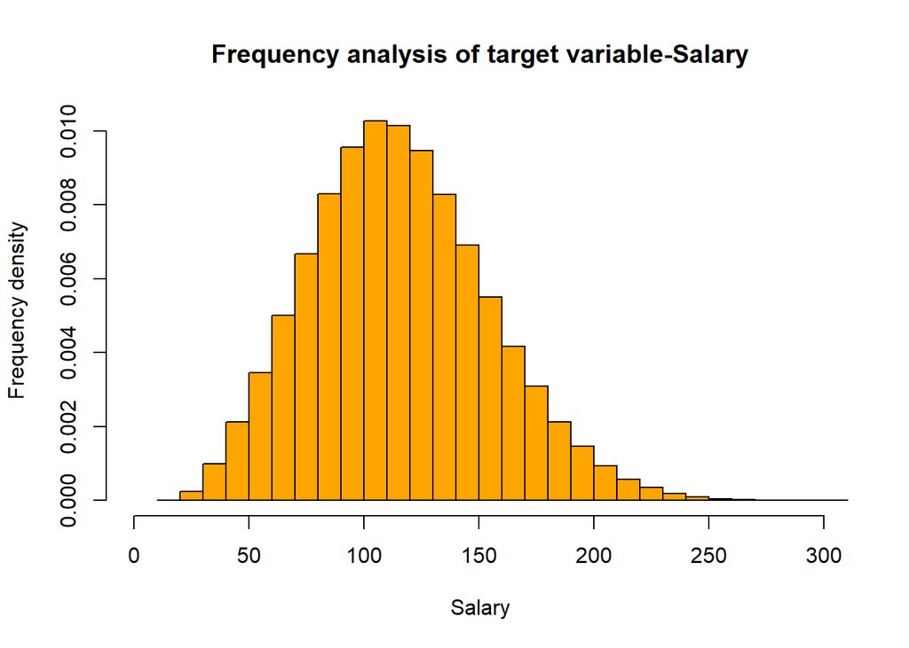

```r
hist(train_salaries$salary,
     main="Frequency analysis of target variable-Salary",
     xlab="Salary",
     ylab="Frequency density",
     xlim=c(0,301),
     col="orange",
     freq=FALSE
)
```

### Analysis of ‘years of experience’ variable

No outliers in the years of experience

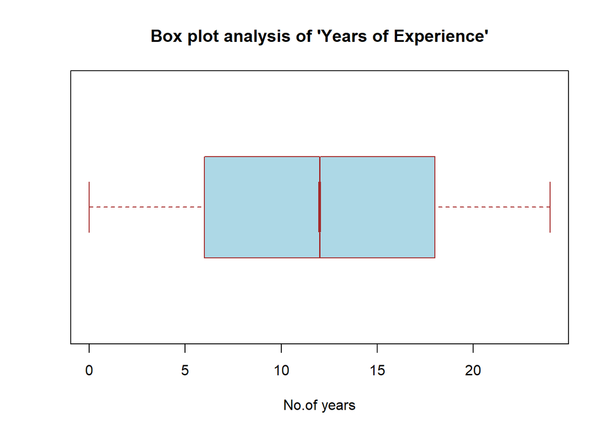

```r
boxplot(train_features$yearsExperience,
        main = "Box plot analysis of 'Years of Experience'",
        xlab = "No.of years",
        col = "light blue",
        border = "brown",
        horizontal = TRUE,
        notch = TRUE
)
```

### Analysis of ‘miles from metroplois’ variable

No outliers in the distance miles of metropolis variable.

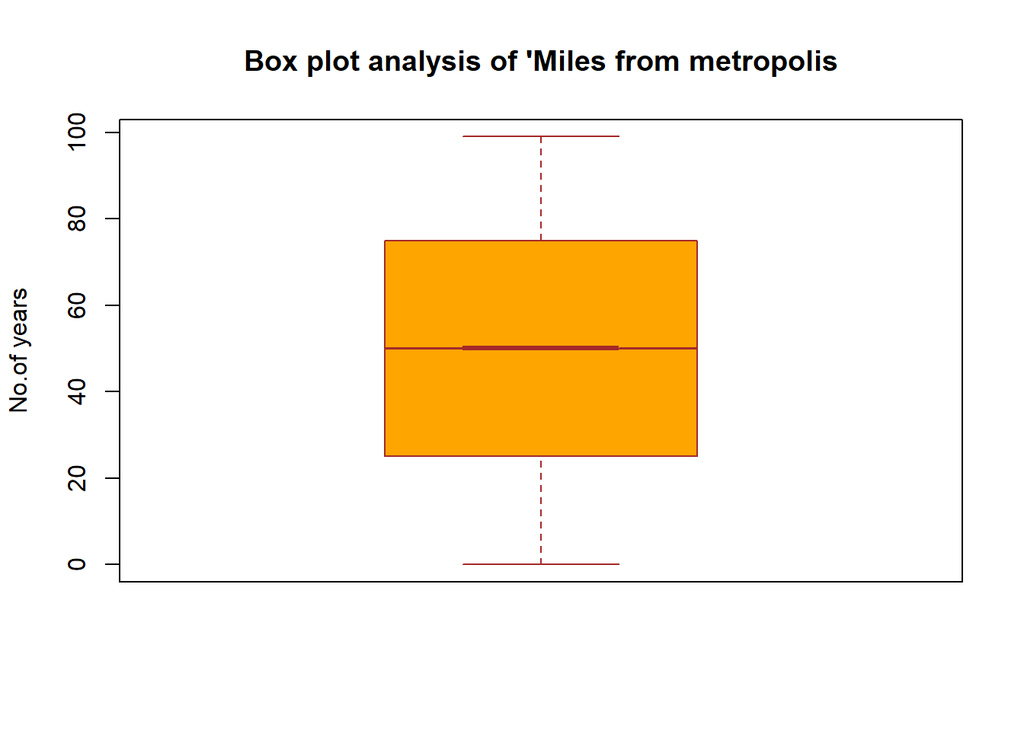

```r
boxplot(train_features$milesFromMetropolis,
        main = "Box plot analysis of 'Miles from metropolis",
        ylab = "No.of years",
        col = "orange",
        border = "brown",
        notch = TRUE)
```

### Frequency analysis of total jobs by Major

‘None’ category holds more than 50% of the total jobs

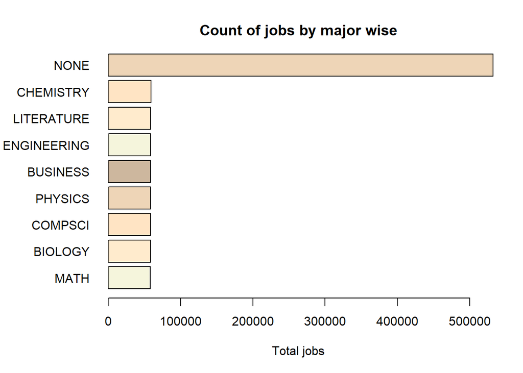

```r
table1<-table(train_features$major)
par(oma=c(1,2,1,1))
par(mar=c(4,5,2,1))
barplot(table1[order(table1)],
        horiz = TRUE,
        las = 1,
        col=c("beige","blanchedalmond","bisque1","bisque2","bisque3"),
        main = "Count of jobs by major wise",  xlab = "Total jobs"
)
```

### Frequency analysis of total jobs by Industry

The total jobs are distributed almost equally among industries.

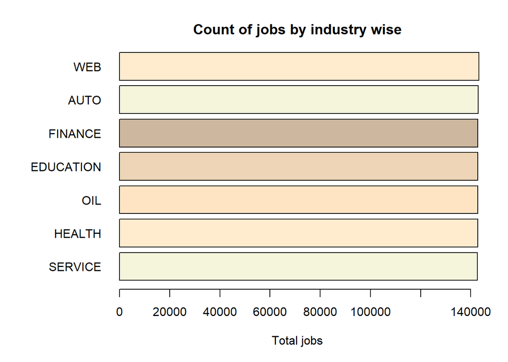

```r
table2<-table(train_features$industry)
par(oma=c(1,3,1,1))
par(mar=c(4,5,2,1))
barplot(table2[order(table2)],
        horiz = TRUE,
        las = 1,
        col=c("beige","blanchedalmond","bisque1","bisque2","bisque3"),
        main = "Count of jobs by industry wise",  xlab = "Total jobs"
)
```

### Frequency analysis of total jobs by degree

High school and None categories have more jobs than other degrees.

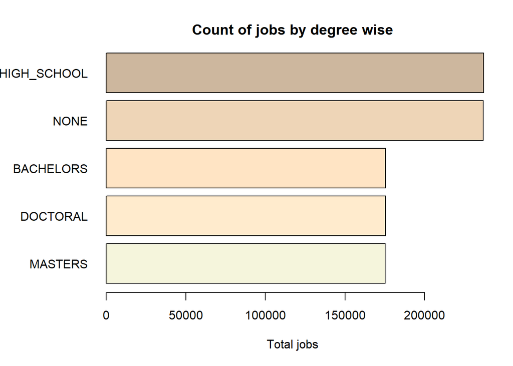

```r
table3<-table(train_features$degree)
par(oma=c(1,2,1,1))
par(mar=c(4,5,2,1))
barplot(table3[order(table3)],
        horiz = TRUE,
        las = 1,
        col=c("beige","blanchedalmond","bisque1","bisque2","bisque3"),
        main = "Count of jobs by degree wise",  xlab = "Total jobs"
)
```

### Merging dependent and independent variables

```r
train_all<-merge(train_features,train_salaries)
```

### Correlation analysis of continous variables

Correlation between experience and salary is only 37% which is weakly correlated.

```r
cor.test(train_all$yearsExperience, train_all$salary,
         method = "pearson")
```

```
##
##  Pearson's product-moment correlation
##
## data:  train_all$yearsExperience and train_all$salary
## t = 404.54, df = 999993, p-value < 0.00000000000000022
## alternative hypothesis: true correlation is not equal to 0
## 95 percent confidence interval:
##  0.3733278 0.3766965
## sample estimates:
##       cor
## 0.3750134
```

Correlation between Miles from metropolis and salary is only negative 29% which is weakly correlated.

```r
cor.test(train_all$milesFromMetropolis, train_all$salary,
         method = "pearson")
```

```
##
##  Pearson's product-moment correlation
##
## data:  train_all$milesFromMetropolis and train_all$salary
## t = -311.82, df = 999993, p-value < 0.00000000000000022
## alternative hypothesis: true correlation is not equal to 0
## 95 percent confidence interval:
##  -0.2994717 -0.2958991
## sample estimates:
##        cor
## -0.2976864
```

Correlation matirx for the continous variables There is no strong relation of continous variables with target variable

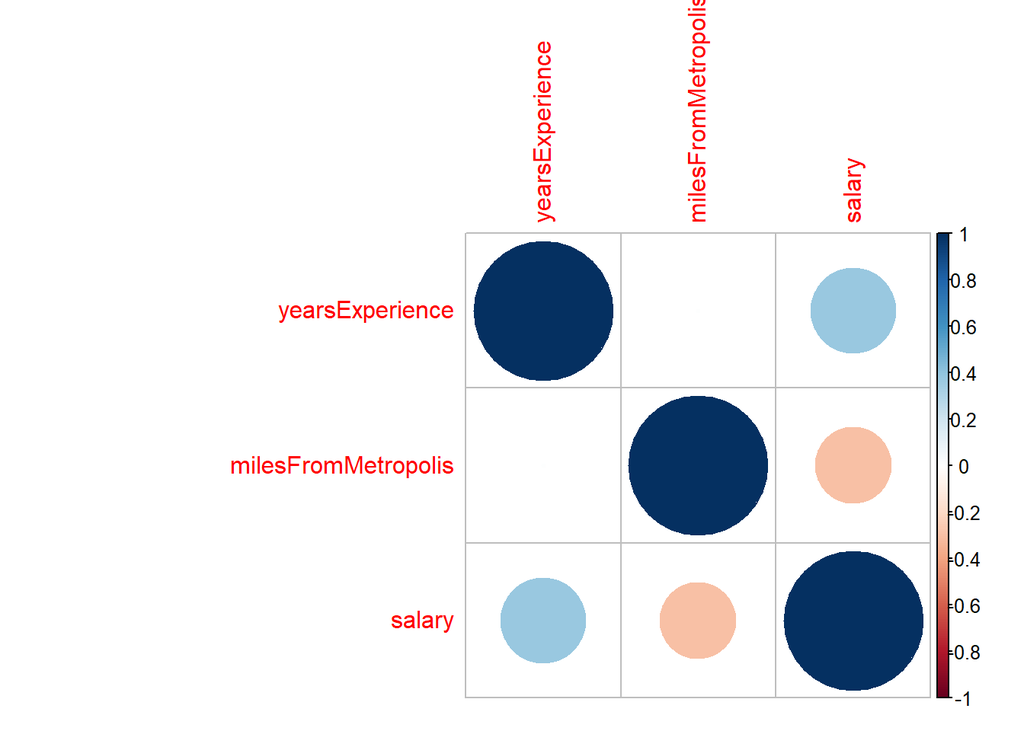

```r
M<-train_all[,c(7,8,9)]
normalize <- function(x) {
  return ((x - min(x)) / (max(x) - min(x)))
}

M$yearsExperience<-normalize(train_all$yearsExperience)
M$salary<-normalize(train_all$salary)
M$milesFromMetropolis<-normalize(train_all$milesFromMetropolis)
M<-as.matrix(M)

library(corrplot)
Mat <- cor(M)
corrplot(Mat, method = "circle")
```

### Correlation analysis of categorical variables

Since correlation cannot be computed directly , we use Analysis of variance method and finding the relation between target and caterogical variables.

Relation between major and salary

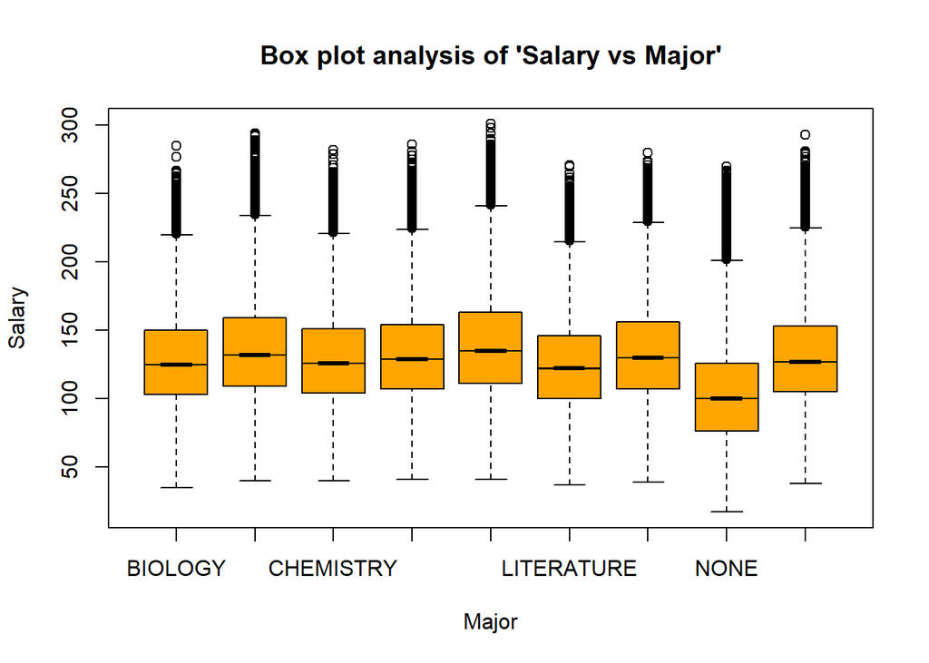

```r
boxplot(train_all$salary~train_all$major,
        main = "Box plot analysis of 'Salary vs Major'",
        xlab = "Major",
        ylab="Salary",
        col = "orange",
        border = "black",
        notch = TRUE)
```

```r
aov1<-aov(train_all$salary~train_all$major)
summary(aov1)
```

```
##                     Df     Sum Sq  Mean Sq F value              Pr(>F)
## train_all$major      8  214949861 26868733   20925 <0.0000000000000002 ***
## Residuals       999986 1284059886     1284
## ---
## Signif. codes:  0 '***' 0.001 '**' 0.01 '*' 0.05 '.' 0.1 ' ' 1
```

Relation between degree and salary

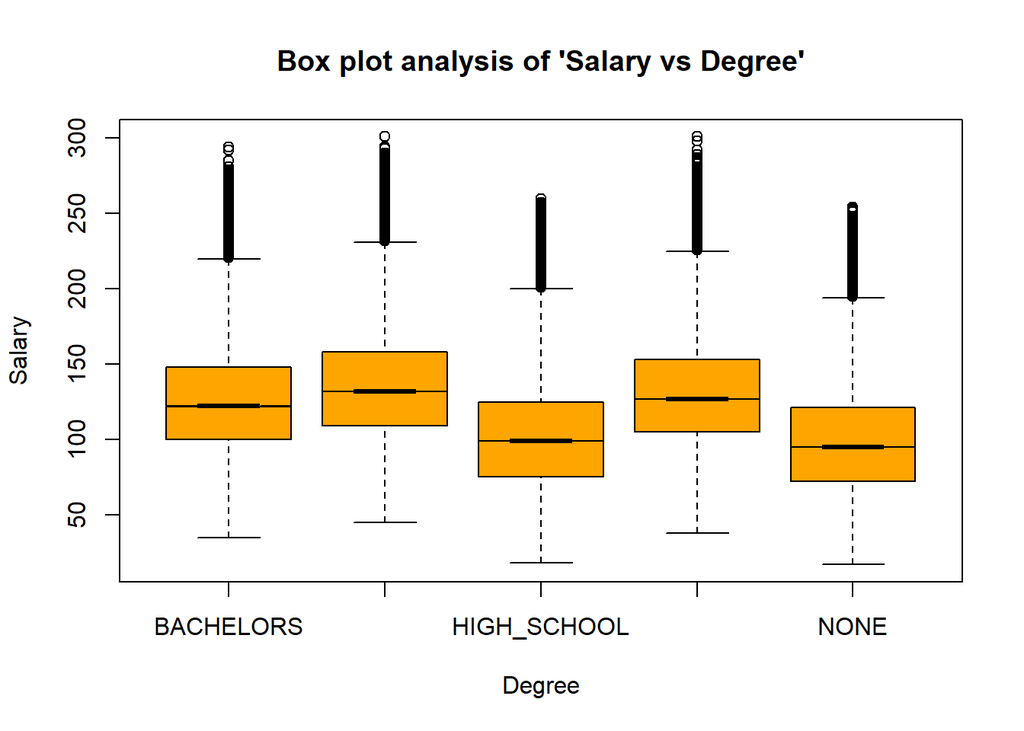

```r
boxplot(train_all$salary~train_all$degree,
        main = "Box plot analysis of 'Salary vs Degree'",
        xlab = "Degree",
        ylab="Salary",
        col = "orange",
        border = "black",
        notch = TRUE)
```

```r
aov2<-aov(train_all$salary~train_all$degree)
summary(aov2)
```

```
##                      Df     Sum Sq  Mean Sq F value              Pr(>F)
## train_all$degree      4  241402844 60350711   47988 <0.0000000000000002 ***
## Residuals        999990 1257606903     1258
## ---
## Signif. codes:  0 '***' 0.001 '**' 0.01 '*' 0.05 '.' 0.1 ' ' 1
```

p-value is very less and significant. There is correlation between the categories of degree with respect to salary

Relation between industry and salary

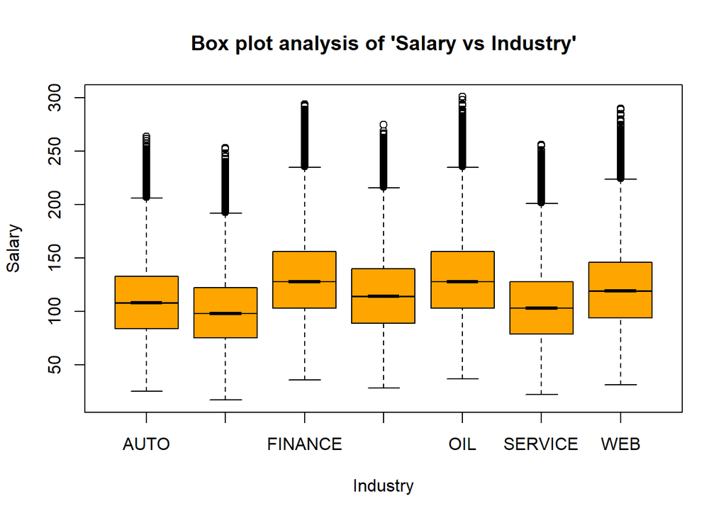

```r
boxplot(train_all$salary~train_all$industry,
        main = "Box plot analysis of 'Salary vs Industry'",
        xlab = "Industry",
        ylab="Salary",
        col = "orange",
        border = "black",
        notch = TRUE)
```

```r
aov3<-aov(train_all$salary~train_all$industry)
summary(aov3)
```

```
##                        Df     Sum Sq  Mean Sq F value              Pr(>F)
## train_all$industry      6  131893631 21982272   16079 <0.0000000000000002 ***
## Residuals          999988 1367116115     1367
## ---
## Signif. codes:  0 '***' 0.001 '**' 0.01 '*' 0.05 '.' 0.1 ' ' 1
```

p-value is very less and significant. There is correlation between the categories of industry with respect to salary

### Baseline model

##### Baseline model is created by using average salary of industry

```r
baseline<-as.data.frame(train_all%>%group_by(industry)%>%summarise(Avg.salary=mean(salary)))

train_all_with_baseline<-merge(train_all,baseline,by.x = "industry",by.y = "industry")

train_all_with_baseline$Square_error<-(train_all_with_baseline$salary-train_all_with_baseline$Avg.salary)^2

mean(train_all_with_baseline$Square_error)
```

```
## [1] 1367.123
```

Mean square error for predicted salary (baseline) is 1367.123

Since the target variable is continous variable , we will use regression models to predict the salary ### Goal to build 3 models and compare the better performing models

# Model 1 using Linear regression.

```r
model1_linear_regression<-lm (formula =salary ~ degree+major+industry+yearsExperience+milesFromMetropolis+jobType , data=train_all)
summary(model1_linear_regression)
```

```
##
## Call:
## lm(formula = salary ~ degree + major + industry + yearsExperience +
##     milesFromMetropolis + jobType, data = train_all)
##
## Residuals:
##     Min      1Q  Median      3Q     Max
## -67.642 -14.178  -0.452  13.267  94.751
##
## Coefficients:
##                          Estimate  Std. Error  t value            Pr(>|t|)
## (Intercept)           134.8692441   0.1231437 1095.219 <0.0000000000000002 ***
## degreeDOCTORAL         10.0319623   0.0661998  151.541 <0.0000000000000002 ***
## degreeHIGH_SCHOOL      -5.7169773   0.0997074  -57.338 <0.0000000000000002 ***
## degreeMASTERS           4.9982425   0.0662048   75.497 <0.0000000000000002 ***
## degreeNONE             -9.4015546   0.0997185  -94.281 <0.0000000000000002 ***
## majorBUSINESS           7.6988638   0.1146880   67.129 <0.0000000000000002 ***
## majorCHEMISTRY          1.0803516   0.1145141    9.434 <0.0000000000000002 ***
## majorCOMPSCI            4.0407512   0.1147549   35.212 <0.0000000000000002 ***
## majorENGINEERING       10.6094192   0.1146510   92.537 <0.0000000000000002 ***
## majorLITERATURE        -3.6204892   0.1146081  -31.590 <0.0000000000000002 ***
## majorMATH               5.1443748   0.1150437   44.717 <0.0000000000000002 ***
## majorNONE              -4.9558693   0.1146847  -43.213 <0.0000000000000002 ***
## majorPHYSICS            2.3262112   0.1147412   20.274 <0.0000000000000002 ***
## industryEDUCATION      -9.9916368   0.0733536 -136.212 <0.0000000000000002 ***
## industryFINANCE        21.1425169   0.0733471  288.253 <0.0000000000000002 ***
## industryHEALTH          6.2457135   0.0733620   85.136 <0.0000000000000002 ***
## industryOIL            21.3087897   0.0733600  290.469 <0.0000000000000002 ***
## industrySERVICE        -4.9819100   0.0733767  -67.895 <0.0000000000000002 ***
## industryWEB            12.1098931   0.0733038  165.201 <0.0000000000000002 ***
## yearsExperience         2.0100671   0.0027184  739.435 <0.0000000000000002 ***
## milesFromMetropolis    -0.3995293   0.0006789 -588.464 <0.0000000000000002 ***
## jobTypeCFO             -9.8029600   0.0785587 -124.785 <0.0000000000000002 ***
## jobTypeCTO             -9.7872758   0.0784521 -124.755 <0.0000000000000002 ***
## jobTypeJANITOR        -62.3581863   0.0825914 -755.020 <0.0000000000000002 ***
## jobTypeJUNIOR         -49.7937022   0.0785236 -634.124 <0.0000000000000002 ***
## jobTypeMANAGER        -29.8656534   0.0784403 -380.744 <0.0000000000000002 ***
## jobTypeSENIOR         -39.7857537   0.0783209 -507.984 <0.0000000000000002 ***
## jobTypeVICE_PRESIDENT -19.9445803   0.0784229 -254.321 <0.0000000000000002 ***
## ---
## Signif. codes:  0 '***' 0.001 '**' 0.01 '*' 0.05 '.' 0.1 ' ' 1
##
## Residual standard error: 19.61 on 999967 degrees of freedom
## Multiple R-squared:  0.7436, Adjusted R-squared:  0.7436
## F-statistic: 1.074e+05 on 27 and 999967 DF,  p-value: < 0.00000000000000022
```

```r
train_all$model1<-predict (model1_linear_regression ,train_all)

train_all$Square_error<-(train_all$salary-train_all$model1)^2

mean(train_all$Square_error)
```

```
## [1] 384.3803
```

Mean square error for predicted salary using Linear regression is 384

# Model 2 using decision trees

```r
model2_decisiontree=rpart(salary~degree+major+industry+yearsExperience+milesFromMetropolis+jobType,data=train_all)

train_all$model2_decisiontree<-predict(model2_decisiontree ,train_all)

train_all$Square_error2<-(train_all$salary-train_all$model2_decisiontree)^2

mean(train_all$Square_error2)
```

```
## [1] 701.934
```

# Model 3 using xgboost

Data has to prepared in the format of matrix for xgboost COnverting categorical features into binary varaibles using one hot encoding

```r
category_vars = c('jobType', 'degree', 'major','industry')
dummy_vars <- dummyVars(~ jobType +  degree + major+industry, data = train_all)
one_hot_encode_category_vars <- as.data.frame(predict(dummy_vars, newdata = train_all))
```

Combining category features and numeric features

```r
xg_model_train_data<-cbind(one_hot_encode_category_vars,train_all[,c(7,8,9)])
y<-as.numeric(xg_model_train_data$salary)
```

Building XG boost Model

```r
xgb <- xgboost(data = data.matrix(xg_model_train_data[,-32]),
               label = y,
               booster = "gblinear",
               objective = "reg:squarederror",
               max.depth = 5,
               nround = 50,
               lambda = 0,
               lambda_bias = 0,
               alpha = 0
)
train_all$xgboost_model = predict(xgb, newdata = as.matrix(xg_model_train_data[,-32]))

train_all$Square_error3<-(train_all$salary-train_all$xgboost_model)^2

mean(train_all$Square_error3)
```

```
## [1] 384.3856
```

# Feature Engineering

Mean ,median ,max and min yearsExperience are computed for each of the category variables( Industry , major, degree,JobType)

```r
train_all<-merge(train_features,train_salaries)

jobType_stats<-train_all%>%group_by(jobType)%>%summarise(avg.salary_jobtype=mean(yearsExperience),median.salary_jobtype=median(yearsExperience),min.salary_jobtype=min(yearsExperience),max.salary_jobtype=max(yearsExperience))
industry_stats<-train_all%>%group_by(industry)%>%summarise(avg.salary_industry=mean(yearsExperience),median.salary_industry=median(yearsExperience),min.salary_industry=min(yearsExperience),max.salary_industry=max(yearsExperience))
degree_stats<-train_all%>%group_by(degree)%>%summarise(avg.salary_degree=mean(yearsExperience),median.salary_degree=median(yearsExperience),min.salary_degree=min(yearsExperience),max.salary_degree=max(yearsExperience))
major_stats<-train_all%>%group_by(major)%>%summarise(avg.salary_major=mean(yearsExperience),median.salary_major=median(yearsExperience),min.salary_major=min(yearsExperience),max.salary_major=max(yearsExperience))


mean_jobtype<-merge(jobType_stats,train_all[,c(1,3)])
mean2_jobtype<-merge(industry_stats,train_all[,c(1,6)])
mean3_jobtype<-merge(degree_stats,train_all[,c(1,4)])
mean4_jobtype<-merge(major_stats,train_all[,c(1,5)])


train_all_new<-merge(train_all,mean_jobtype,by="jobId")
train_all_new<-merge(train_all_new,mean2_jobtype,by="jobId")
train_all_new<-merge(train_all_new,mean3_jobtype,by="jobId")
train_all_new<-merge(train_all_new,mean4_jobtype,by="jobId")
final_data_<-train_all_new[,c(-1,-2,-10,-15,-20,-25)]
names(final_data_)[1]<-"jobType"
names(final_data_)[2]<-"degree"
names(final_data_)[3]<-"major"
names(final_data_)[4]<-"industry"
```

```r
dummy_vars <- dummyVars(~ jobType +  degree + major+industry, data = train_all)
one_hot_encode_category_vars <- as.data.frame(predict(dummy_vars, newdata = final_data_))
xg_model_train_data<-cbind(one_hot_encode_category_vars,final_data_[,c(-1,-2,-3,-4)])
names(xg_model_train_data) <- gsub("[.]", "", names(xg_model_train_data))
y<-as.numeric(xg_model_train_data$salary)
```

# Linear regression model after feature engineering

The MSE for linear regression model after feature engineering is 384

```r
model1_linear_regression<-lm (formula =salary ~ . , data=final_data_)
summary(model1_linear_regression)
```

```
##
## Call:
## lm(formula = salary ~ ., data = final_data_)
##
## Residuals:
##     Min      1Q  Median      3Q     Max
## -67.642 -14.178  -0.452  13.267  94.751
##
## Coefficients: (15 not defined because of singularities)
##                                  Estimate         Std. Error  t value
## (Intercept)             530458611.0194679 6450258502.5445757    0.082
## jobTypeCFO                     -9.8029729          0.0785589 -124.785
## jobTypeCTO                     -9.7872759          0.0784521 -124.755
## jobTypeJANITOR                -62.3581882          0.0825915 -755.020
## jobTypeJUNIOR                 -49.7937024          0.0785236 -634.124
## jobTypeMANAGER                -29.8656535          0.0784403 -380.744
## jobTypeSENIOR                 -39.7857537          0.0783209 -507.984
## jobTypeVICE_PRESIDENT         -19.9445802          0.0784229 -254.321
## degreeDOCTORAL                 10.0319623          0.0661998  151.541
## degreeHIGH_SCHOOL              -5.7169803          0.0997074  -57.338
## degreeMASTERS                   4.9982333          0.0662049   75.496
## degreeNONE                     -9.4015576          0.0997185  -94.281
## majorBUSINESS                   7.6988638          0.1146881   67.129
## majorCHEMISTRY                  1.0803516          0.1145142    9.434
## majorCOMPSCI                    4.0407512          0.1147550   35.212
## majorENGINEERING               10.6094191          0.1146510   92.537
## majorLITERATURE                -3.6204892          0.1146082  -31.590
## majorMATH                       5.1443470          0.1150443   44.716
## majorNONE                      -4.9558693          0.1146847  -43.213
## majorPHYSICS                    2.3262112          0.1147412   20.274
## industryEDUCATION         1124641.1442316   13675510.6717848    0.082
## industryFINANCE           1548534.0036648   18829576.1082162    0.082
## industryHEALTH             -82443.7669856    1002574.0361560   -0.082
## industryOIL               1410749.1702840   17154140.7904712    0.082
## industrySERVICE            883656.1682406   10745125.4026394    0.082
## industryWEB                601257.2136889    7311008.3394612    0.082
## yearsExperience                 2.0100672          0.0027184  739.434
## milesFromMetropolis            -0.3995294          0.0006789 -588.464
## avg.salary_jobtype                     NA                 NA       NA
## median.salary_jobtype                  NA                 NA       NA
```

[output cut: 50 more lines]

```
## max.salary_industry                     NA
## avg.salary_degree                       NA
## median.salary_degree                    NA
## min.salary_degree                       NA
## max.salary_degree                       NA
## avg.salary_major                        NA
## median.salary_major                     NA
## min.salary_major                        NA
## max.salary_major                        NA
## ---
## Signif. codes:  0 '***' 0.001 '**' 0.01 '*' 0.05 '.' 0.1 ' ' 1
##
## Residual standard error: 19.61 on 999966 degrees of freedom
## Multiple R-squared:  0.7436, Adjusted R-squared:  0.7436
## F-statistic: 1.036e+05 on 28 and 999966 DF,  p-value: < 0.00000000000000022
```

```r
train_all$model1<-predict (model1_linear_regression ,final_data_)
train_all$Square_error<-(train_all$salary-train_all$model1)^2

mean(train_all$Square_error)
```

```
## [1] 384.3803
```

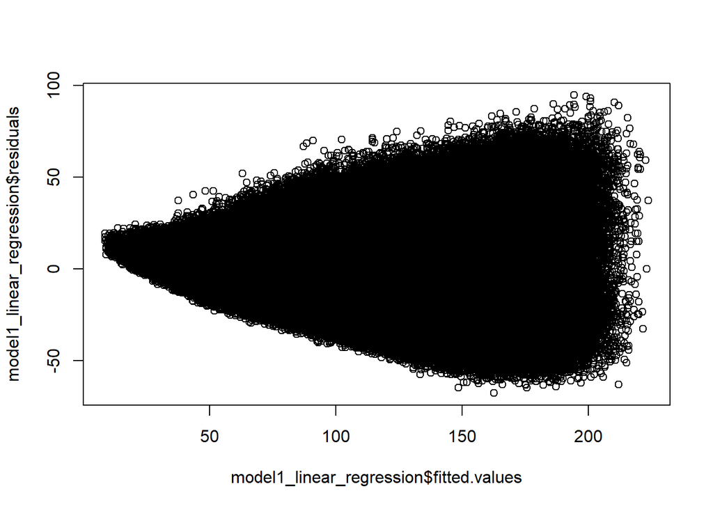

```r
plot(model1_linear_regression$fitted.values,model1_linear_regression$residuals)
```

From the plot there exists heteroskedasticity ie) larger differences occur when response value is larger

# Decision tree model after feature engineering

The MSE for decision tree model after feature engineering is 701

```r
model2_decisiontree=rpart(salary~.,data=final_data_)

train_all$model2_decisiontree<-predict(model2_decisiontree ,final_data_)

train_all$Square_error2<-(train_all$salary-train_all$model2_decisiontree)^2

mean(train_all$Square_error2)
```

```
## [1] 701.934
```

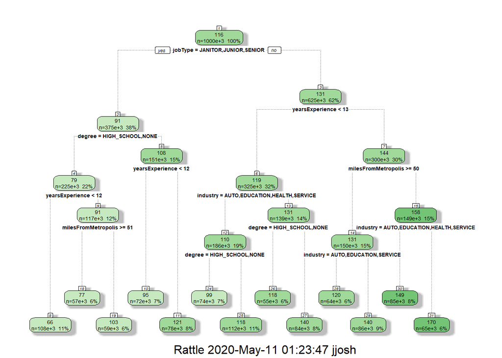

```r
fancyRpartPlot(model2_decisiontree)
```

# XG boost model after feature engineering

Building XG boost Model

```r
xg_model_train_data[,c(1:48)] <-round(xg_model_train_data[,c(1:48)],0)
xgb_final <-xgboost(data = data.matrix(xg_model_train_data[,-32]),
                    label = y,
                    booster = "gblinear",
                    objective = "reg:squarederror",
                    max.depth = 5,
                    nround = 50,
                    lambda = 0,
                    lambda_bias = 0,
                    alpha = 0
)
xg_model_train_data$xgboost_model = predict(xgb_final, newdata = as.matrix(xg_model_train_data[,-32]))

xg_model_train_data$Square_error3<-(xg_model_train_data$salary-xg_model_train_data$xgboost_model)^2

mean(xg_model_train_data$Square_error3)
```

```
## [1] 384.3924
```